# PCA

Principal Component Analysis (PCA) is a powerful linear dimensionality reduction technique. It reduces dimensionality of data while preserving as much of the original information as possible.

- Used to reduce the dimensionality of the data by representing a large number of variables with a fewer number of components. Similar variables get grouped into the same component while dissimilar variables are placed in different components.
- Like factor analysis, it reduces the data based on similarity (typically inferred from correlation).
- It is used when the primary concern is to determine the minimum number of components that will account for maximum variance in the data for use in subsequent machine learning tasks.
- Not concerned with uncovering meaning of components.
- This reduced number of components can be used for further analysis instead of the original set of variables.
- Is computationally efficient.
- Most widely used dimension reduction technique.

## PCA with Diabetes Data

The diabetes dataset contains 442 observations on 10 markers of diabetes.

```python
import matplotlib.pyplot as plt
import seaborn as sns
import numpy as np
import pandas as pd
from sklearn.datasets import load_diabetes
diabetes_features = load_diabetes().data
diabetes_progression = load_diabetes().target
```

### Explore Data

```python
diabetes_df = pd.DataFrame(diabetes_features, columns=load_diabetes().feature_names)
diabetes_df.head()
```

|  | age | sex | bmi | bp | s1 | s2 | s3 | s4 | s5 | s6 |
| --- | --- | --- | --- | --- | --- | --- | --- | --- | --- | --- |
| 0 | 0.038076 | 0.050680 | 0.061696 | 0.021872 | -0.044223 | -0.034821 | -0.043401 | -0.002592 | 0.019907 | -0.017646 |
| 1 | -0.001882 | -0.044642 | -0.051474 | -0.026328 | -0.008449 | -0.019163 | 0.074412 | -0.039493 | -0.068332 | -0.092204 |
| 2 | 0.085299 | 0.050680 | 0.044451 | -0.005670 | -0.045599 | -0.034194 | -0.032356 | -0.002592 | 0.002861 | -0.025930 |
| 3 | -0.089063 | -0.044642 | -0.011595 | -0.036656 | 0.012191 | 0.024991 | -0.036038 | 0.034309 | 0.022688 | -0.009362 |
| 4 | 0.005383 | -0.044642 | -0.036385 | 0.021872 | 0.003935 | 0.015596 | 0.008142 | -0.002592 | -0.031988 | -0.046641 |

```python
diabetes_df.describe()
```

|  | age | sex | bmi | bp | s1 | s2 | s3 | s4 | s5 | s6 |
| --- | --- | --- | --- | --- | --- | --- | --- | --- | --- | --- |
| count | 4.420000e+02 | 4.420000e+02 | 4.420000e+02 | 4.420000e+02 | 4.420000e+02 | 4.420000e+02 | 4.420000e+02 | 4.420000e+02 | 4.420000e+02 | 4.420000e+02 |
| mean | -2.511817e-19 | 1.230790e-17 | -2.245564e-16 | -4.797570e-17 | -1.381499e-17 | 3.918434e-17 | -5.777179e-18 | -9.042540e-18 | 9.293722e-17 | 1.130318e-17 |
| std | 4.761905e-02 | 4.761905e-02 | 4.761905e-02 | 4.761905e-02 | 4.761905e-02 | 4.761905e-02 | 4.761905e-02 | 4.761905e-02 | 4.761905e-02 | 4.761905e-02 |
| min | -1.072256e-01 | -4.464164e-02 | -9.027530e-02 | -1.123988e-01 | -1.267807e-01 | -1.156131e-01 | -1.023071e-01 | -7.639450e-02 | -1.260971e-01 | -1.377672e-01 |
| 25% | -3.729927e-02 | -4.464164e-02 | -3.422907e-02 | -3.665608e-02 | -3.424784e-02 | -3.035840e-02 | -3.511716e-02 | -3.949338e-02 | -3.324559e-02 | -3.317903e-02 |
| 50% | 5.383060e-03 | -4.464164e-02 | -7.283766e-03 | -5.670422e-03 | -4.320866e-03 | -3.819065e-03 | -6.584468e-03 | -2.592262e-03 | -1.947171e-03 | -1.077698e-03 |
| 75% | 3.807591e-02 | 5.068012e-02 | 3.124802e-02 | 3.564379e-02 | 2.835801e-02 | 2.984439e-02 | 2.931150e-02 | 3.430886e-02 | 3.243232e-02 | 2.791705e-02 |
| max | 1.107267e-01 | 5.068012e-02 | 1.705552e-01 | 1.320436e-01 | 1.539137e-01 | 1.987880e-01 | 1.811791e-01 | 1.852344e-01 | 1.335973e-01 | 1.356118e-01 |

## Data Preparation

- Missing values: Impute missing values to avoid listwise deletion, the default.
- Standardize Variables: PCA is sensitive to measurement scale.

### Suitability

PCA groups similar features to reduce dimensionality. Similarity is judged by Pearson’s correlation. For PCA to work, there needs to be a pattern of correlations across the features.

```python
diabetes_df.corr().round(2)
```

|  | age | sex | bmi | bp | s1 | s2 | s3 | s4 | s5 | s6 |
| --- | --- | --- | --- | --- | --- | --- | --- | --- | --- | --- |
| age | 1.00 | 0.17 | 0.19 | 0.34 | 0.26 | 0.22 | -0.08 | 0.20 | 0.27 | 0.30 |
| sex | 0.17 | 1.00 | 0.09 | 0.24 | 0.04 | 0.14 | -0.38 | 0.33 | 0.15 | 0.21 |
| bmi | 0.19 | 0.09 | 1.00 | 0.40 | 0.25 | 0.26 | -0.37 | 0.41 | 0.45 | 0.39 |
| bp | 0.34 | 0.24 | 0.40 | 1.00 | 0.24 | 0.19 | -0.18 | 0.26 | 0.39 | 0.39 |
| s1 | 0.26 | 0.04 | 0.25 | 0.24 | 1.00 | 0.90 | 0.05 | 0.54 | 0.52 | 0.33 |
| s2 | 0.22 | 0.14 | 0.26 | 0.19 | 0.90 | 1.00 | -0.20 | 0.66 | 0.32 | 0.29 |
| s3 | -0.08 | -0.38 | -0.37 | -0.18 | 0.05 | -0.20 | 1.00 | -0.74 | -0.40 | -0.27 |
| s4 | 0.20 | 0.33 | 0.41 | 0.26 | 0.54 | 0.66 | -0.74 | 1.00 | 0.62 | 0.42 |
| s5 | 0.27 | 0.15 | 0.45 | 0.39 | 0.52 | 0.32 | -0.40 | 0.62 | 1.00 | 0.46 |
| s6 | 0.30 | 0.21 | 0.39 | 0.39 | 0.33 | 0.29 | -0.27 | 0.42 | 0.46 | 1.00 |

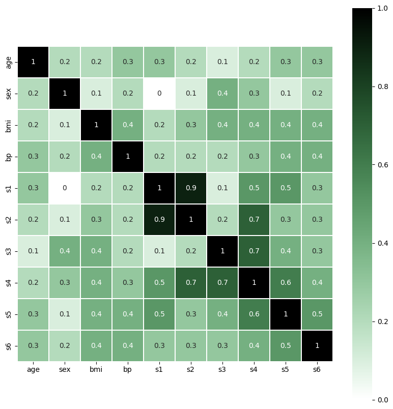

```python
plt.figure(figsize=(10,10))
pal = sns.cubehelix_palette(start=2, rot=0, dark=1, light=0, reverse=True, as_cmap=True)
sns.heatmap(round(diabetes_df.corr().abs(),1), annot=True, cmap=pal,
            linewidths=0.2, square=True);
```

### Data Preparation

- Missing Values: Principal Components Analysis uses data on all variables. A missing observation on one variable will cause the entire row of data to be ignored for analysis. Therefore, it is important to impute missing values.
- Standardize: It is important to standardize variables to ensure they receive the same weight in analysis.
- Split Data: Generate PCA schema using train sample and apply it to test sample.
- Drop outcome variable: PCA is an unsupervised learning technique, so it only operates on features.

The data used does not have any missing values and the outcome variable has already been dropped. To keep it simple, in this illustration, we are not splitting the data.

```python
from sklearn.decomposition import PCA
from sklearn.preprocessing import StandardScaler
scale = StandardScaler()
diabetes_features_scaled = scale.fit_transform(diabetes_features)
pca = PCA(n_components = 10)
pca.fit(diabetes_features_scaled)
```

```
PCA(n_components=10)
```

### Number of Components

PCA will transform p features into p components. The overarching goal of PCA is to pick out the components that maximize variance extracted. This can be done a few different ways:

- Variance Threshold: Set a threshold, say 70%, for the variance to be extracted. Based on this the algorithm will decide on number of components to be extracted.
- Eigen Value: Drop components with an eigen less than or equal to 1
- Scree Plot: Line graph of eigen values for each component. Ideal number of factors is indicated by a sudden change in the line graph or what is known as the elbow.

```python
eigen_table = pd.DataFrame({'num_components':range(1,11),
                          'eigen_value': pca.explained_variance_,
                          'variance_explained':100 * pca.explained_variance_ratio_})
eigen_table
```

|  | num_components | eigen_value | variance_explained |
| --- | --- | --- | --- |
| 0 | 1 | 4.033336 | 40.242108 |
| 1 | 2 | 1.495704 | 14.923197 |
| 2 | 3 | 1.208701 | 12.059663 |
| 3 | 4 | 0.957643 | 9.554764 |
| 4 | 5 | 0.663683 | 6.621814 |
| 5 | 6 | 0.604084 | 6.027171 |
| 6 | 7 | 0.537782 | 5.365657 |
| 7 | 8 | 0.434665 | 4.336820 |
| 8 | 9 | 0.078498 | 0.783200 |
| 9 | 10 | 0.008580 | 0.085607 |

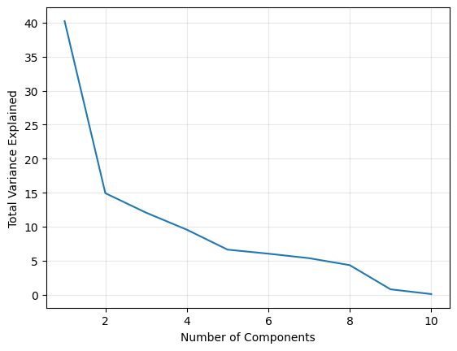

```python
plt.plot(eigen_table.num_components, eigen_table.variance_explained)
plt.grid(alpha = 0.3)
plt.ylabel('Total Variance Explained')
plt.xlabel('Number of Components')
plt.show()
```

### Derive Components

In order to use the components, for downstream analysis,

- apply the component structure to the test set.
- extract the components.
- combine components with other variables in the original dataset.

```python
pca = PCA(n_components = 4)
pca.fit(diabetes_features_scaled)
diabetes_components = pca.transform(diabetes_features_scaled)
diabetes_components
```

```
array([[ 0.58719913, -1.9468322 ,  0.58920548,  0.08281558],
       [-2.83162538,  1.37208173,  0.02792987,  0.47000841],
       [ 0.27212855, -1.63490124,  0.73924374,  0.79149227],
       ...,
       [-0.20520638, -1.20548723,  0.4961862 ,  1.35336985],
       [ 0.69287112,  0.2101271 , -0.86872416, -1.61679332],
       [-1.90394067,  3.97577657, -0.04833791,  0.22062889]],
      shape=(442, 4))
```

```python
pd.DataFrame(diabetes_components, columns=['PC1','PC2','PC3','PC4']).assign(progression = diabetes_progression)
```

|  | PC1 | PC2 | PC3 | PC4 | progression |
| --- | --- | --- | --- | --- | --- |
| 0 | 0.587199 | -1.946832 | 0.589205 | 0.082816 | 151.0 |
| 1 | -2.831625 | 1.372082 | 0.027930 | 0.470008 | 75.0 |
| 2 | 0.272129 | -1.634901 | 0.739244 | 0.791492 | 141.0 |
| 3 | 0.049281 | 0.382278 | -2.013032 | -1.373216 | 206.0 |
| 4 | -0.756421 | 0.811960 | -0.057238 | 0.137495 | 135.0 |
| ... | ... | ... | ... | ... | ... |
| 437 | 1.239525 | -1.035968 | 0.928679 | 0.656264 | 178.0 |
| 438 | 1.264719 | 0.761319 | -1.750191 | 1.133464 | 104.0 |
| 439 | -0.205206 | -1.205487 | 0.496186 | 1.353370 | 132.0 |
| 440 | 0.692871 | 0.210127 | -0.868724 | -1.616793 | 220.0 |
| 441 | -1.903941 | 3.975777 | -0.048338 | 0.220629 | 57.0 |

442 rows × 5 columns

## PCA Features for Predictive Modeling

### Split Data

```python
from sklearn.model_selection import train_test_split
X_train, X_test, y_train, y_test = train_test_split(diabetes_features, diabetes_progression, test_size=0.25, random_state=617)
```

### Transform Data

```python
from sklearn.preprocessing import StandardScaler
scale = StandardScaler()
scale.fit(X_train)
X_train_scaled = scale.transform(X_train)
X_test_scaled = scale.transform(X_test)
```

### Run PCA

We have decided to go with a component structure that retains 70% of the variance.

```python
from sklearn.decomposition import PCA
pca = PCA(n_components=0.7)
pca.fit(X_train_scaled)
X_train_components = pca.transform(X_train_scaled)
X_test_components = pca.transform(X_test_scaled)
X_test_components.shape
```

```
(111, 4)
```

### Predictive Model

Use components instead of original features to predict outcome

```python
from sklearn.linear_model import LinearRegression
lm = LinearRegression()
lm.fit(X_train_components, y_train)
pred_test = lm.predict(X_test_components)
from sklearn.metrics import root_mean_squared_error
root_mean_squared_error(y_test, pred_test)
```

```
54.03011657203701
```

### Baseline Model

As a baseline for comparison, we will use a model with all the raw features.

```python
from sklearn.linear_model import LinearRegression
lm = LinearRegression()
lm.fit(X_train, y_train)
pred_test = lm.predict(X_test)
from sklearn.metrics import root_mean_squared_error
root_mean_squared_error(y_test, pred_test)
```

```
53.35686198874997
```

## PCA for Image Compression

PCA reduces dimensionality of data while retaining most of the information in the data. To visualize the effects of PCA, we will use the MNIST dataset. MNIST is a collection of over 70,000 handwritten digits. Each digit is expressed as a grayscale image. as illustrated below.

### MNIST Data

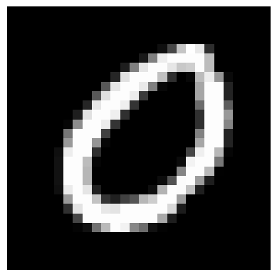

```python
from sklearn.datasets import fetch_openml
from sklearn.model_selection import train_test_split
mnist = fetch_openml('mnist_784',as_frame=False)
X = mnist.data
y = mnist.target
X_train, X_test, y_train, y_test = train_test_split(X, y, test_size=0.3, random_state=1031)

import matplotlib.pyplot as plt
def plot_digit(image_data):
    image = image_data.reshape(28, 28)
    plt.imshow(image, cmap="gray")
    plt.axis("off")
plot_digit(X_test[617])
```

### PCA

Run a PCA, keeping 70% of the original information. The schema is then applied to the test data.

```python
from sklearn.decomposition import PCA
pca = PCA(n_components=0.7)
pca.fit(X_train)
X_test_pca = pca.transform(X_test)
```

### Recover Original Structure

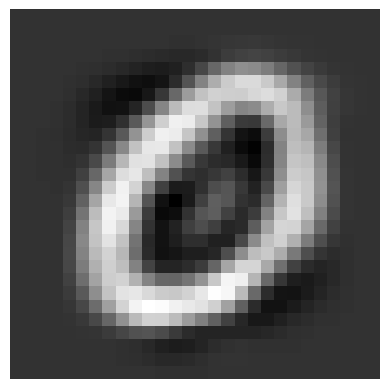

```python
X_test_recovered = pca.inverse_transform(X_test_pca)
plot_digit(X_test_recovered[617])
```

## Summary

This note examined the use of Principle Component Analysis. Specifically we

- Conducted PCA on Diabetes features
- Conducted PCA and used components in a predictive model
- Used PCA for image compression

This file was generated using Python 3.13.5 on Windows 10 with the following libraries: matplotlib 3.10.3, numpy 2.3.1, pandas 2.3.0, scikit-learn 1.7.1, seaborn 0.13.2